# Developmental ToM: cross-task fine-tuning transfer

### 7B Pretrained

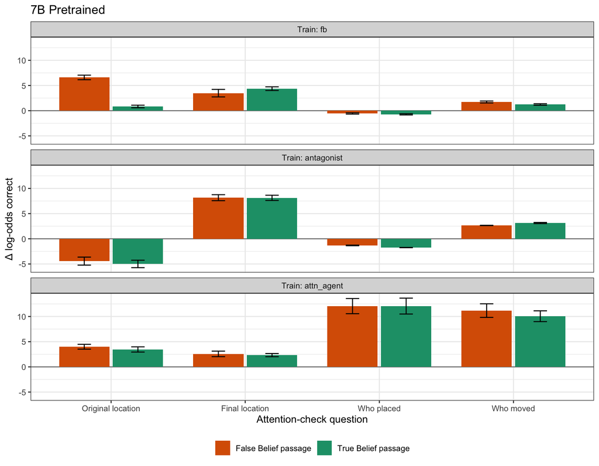

### 7B SFT

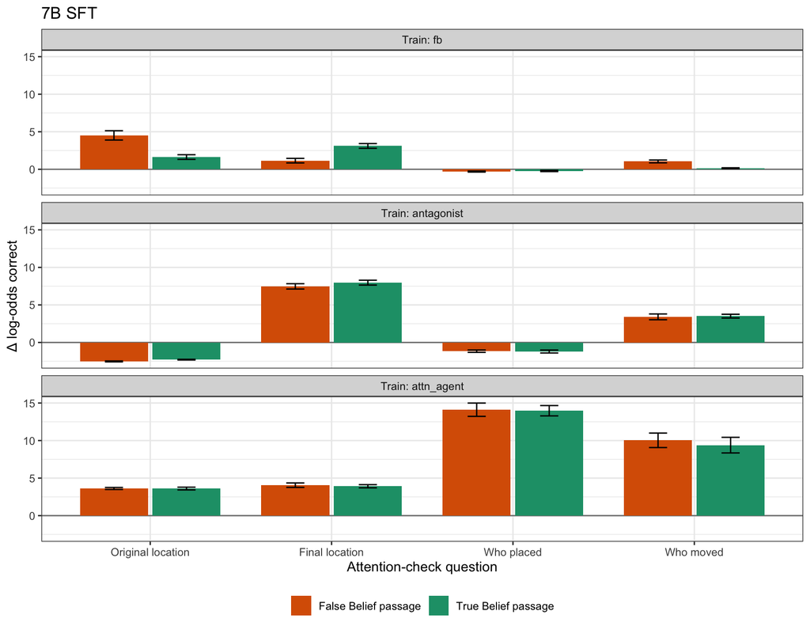

### 7B DPO

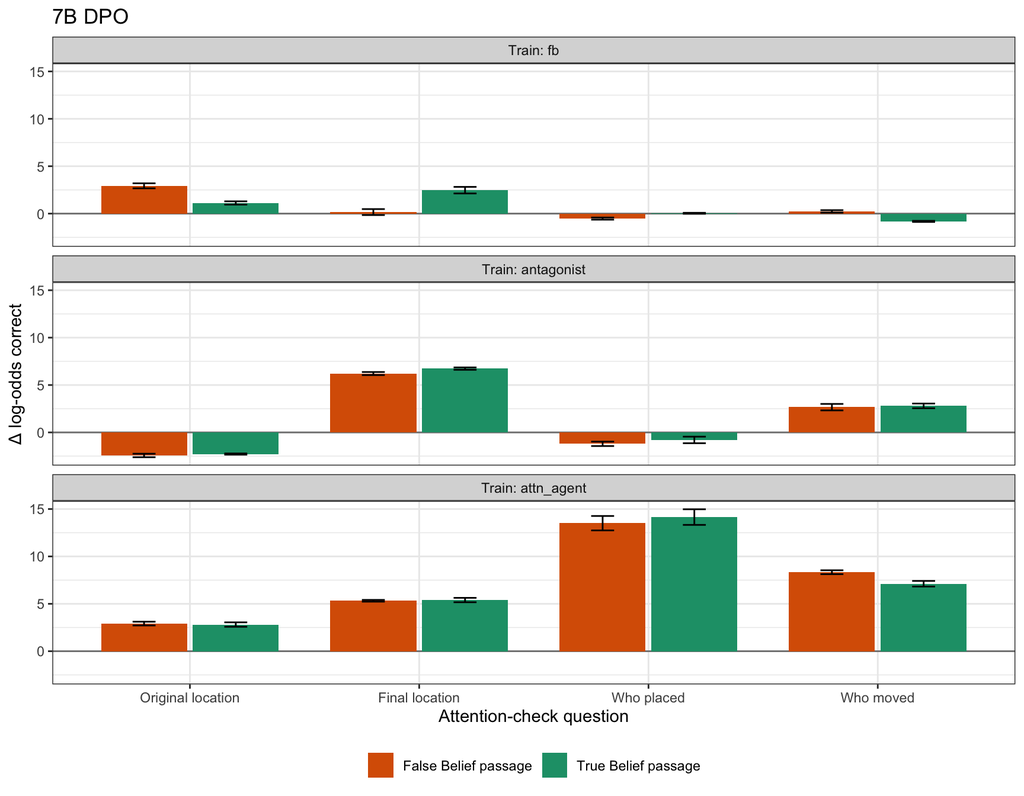

### 7B Instruct

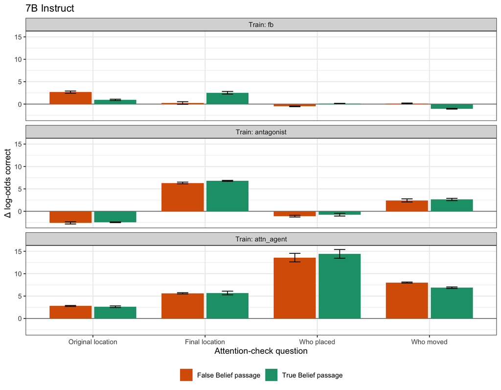

### 13B Stage 1

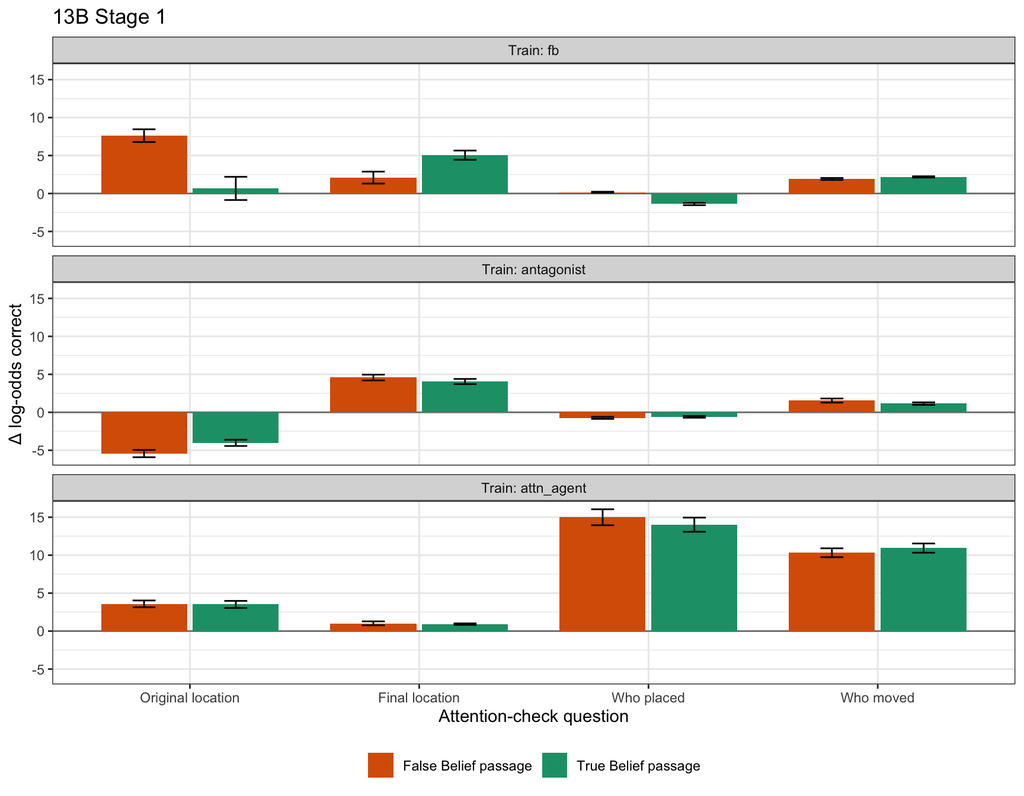

### 13B Stage 2

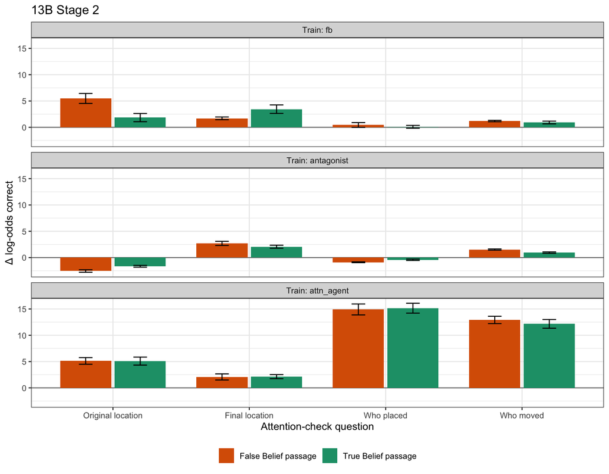

### 13B Pretrained

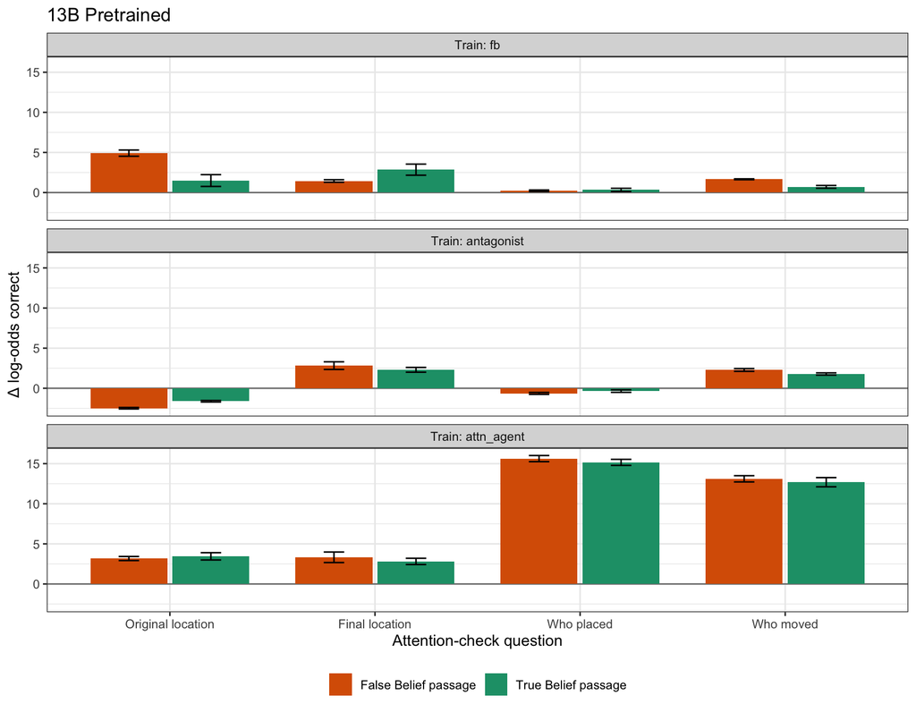

### 13B SFT

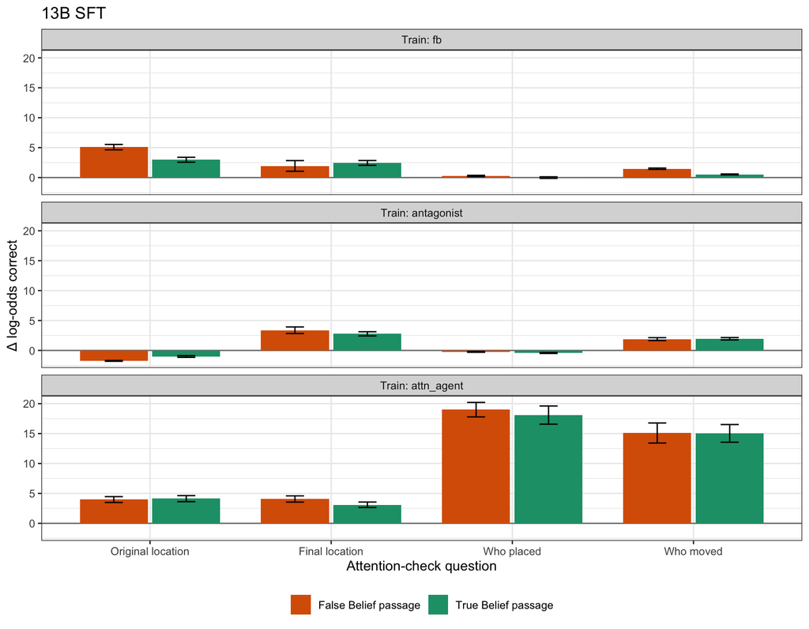

### 13B DPO

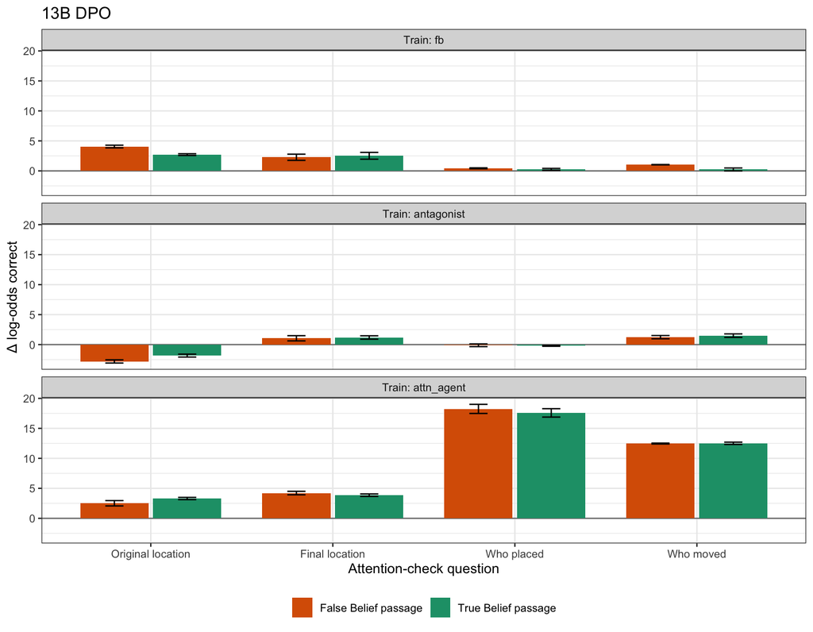

### 13B Instruct

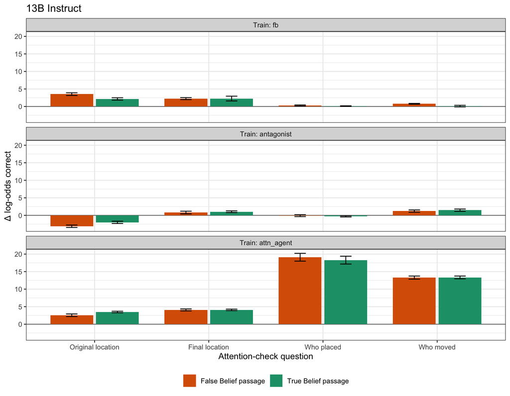

## Accuracy

Change in accuracy (percentage points), where an item counts as correct if the model gives the correct answer higher probability than the incorrect one. Labels show accuracy before → after fine-tuning.

### 7B Stage 1

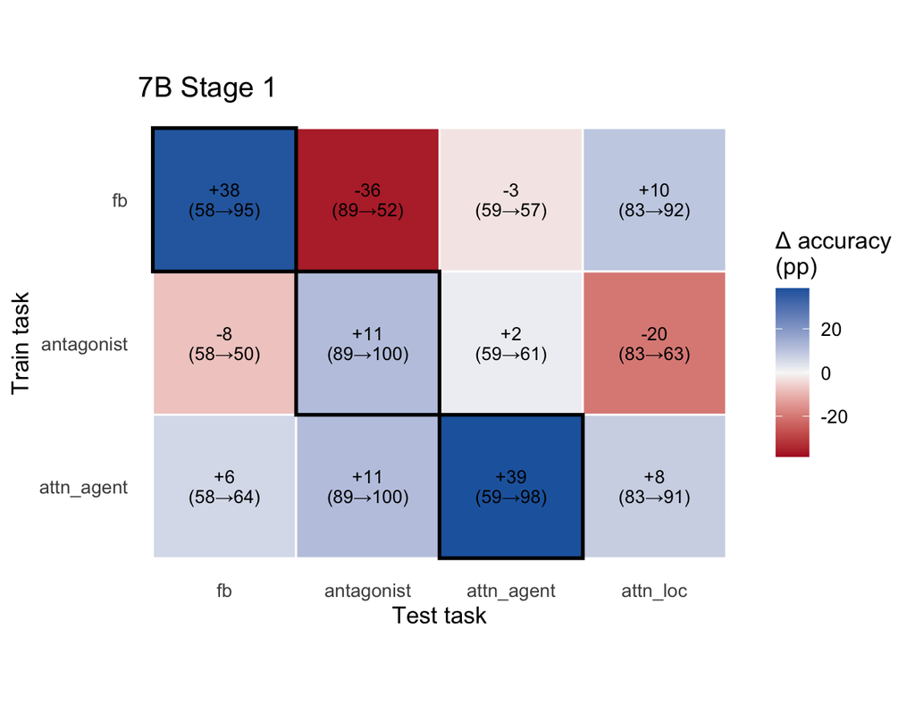

### 7B Stage 2

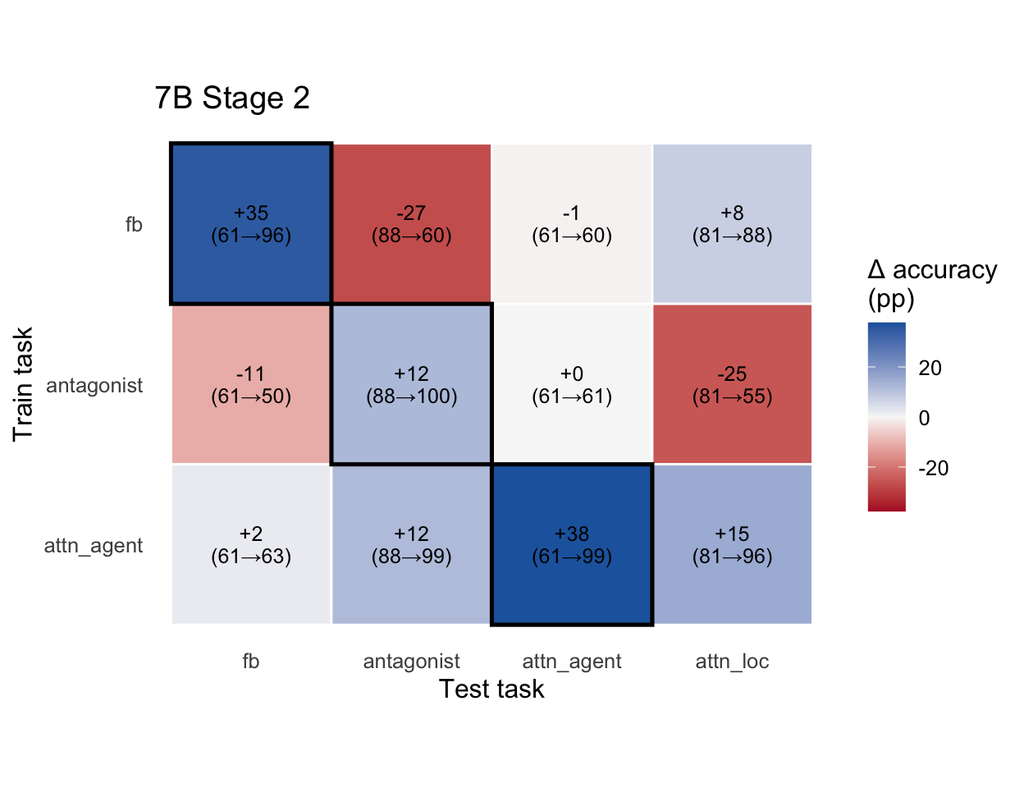

### 7B Pretrained

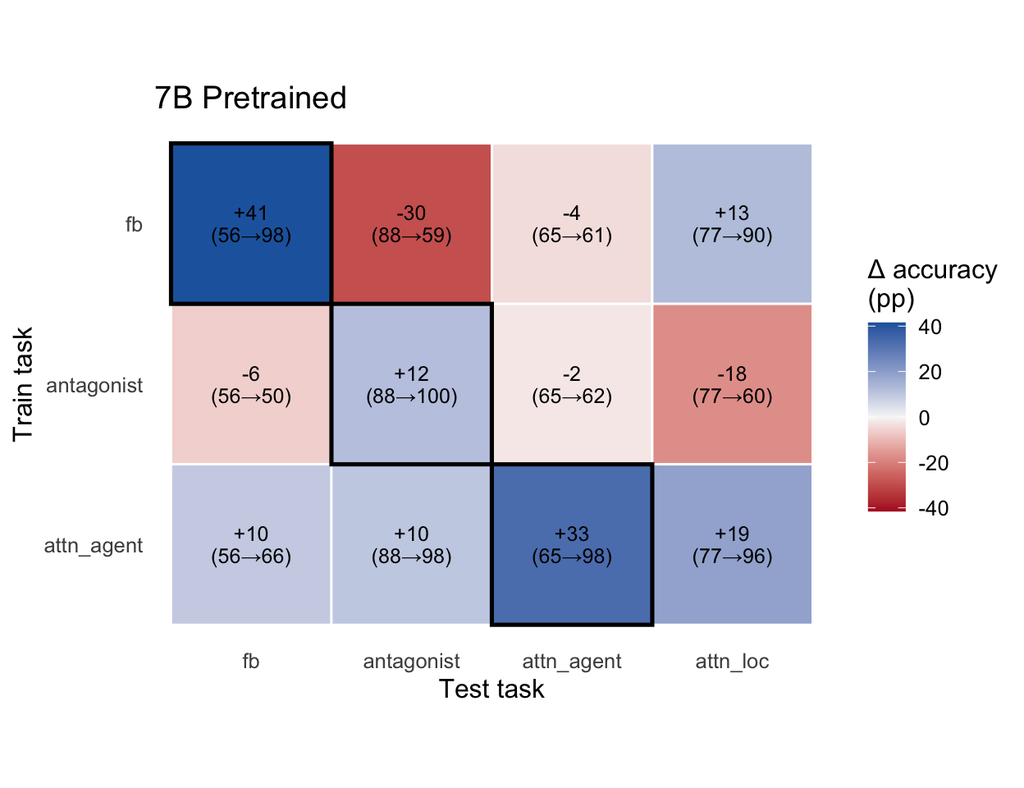

### 7B SFT

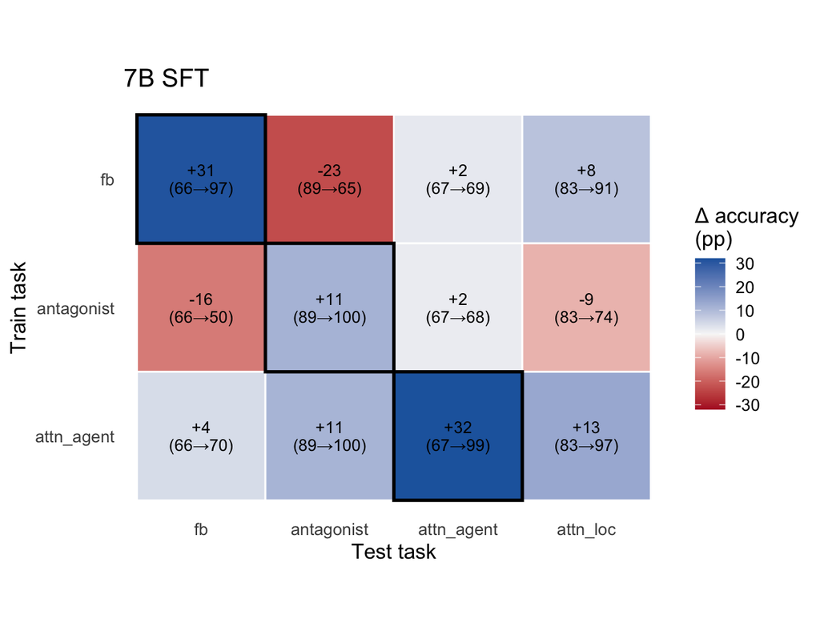

### 7B DPO

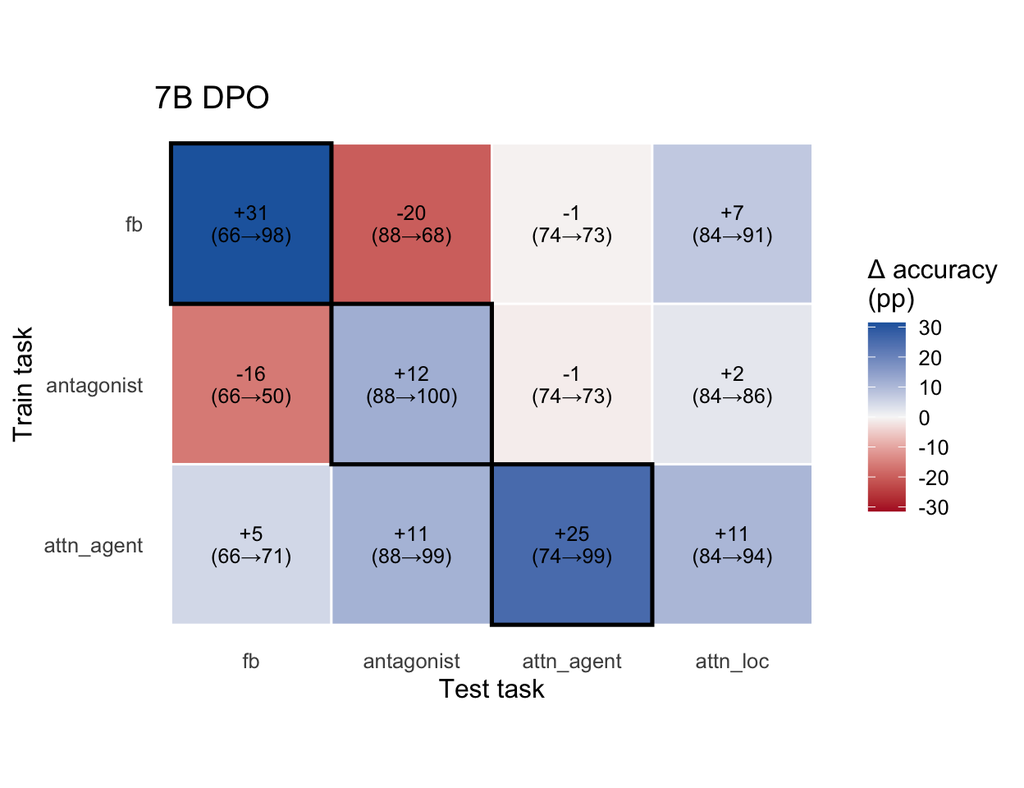

### 7B Instruct

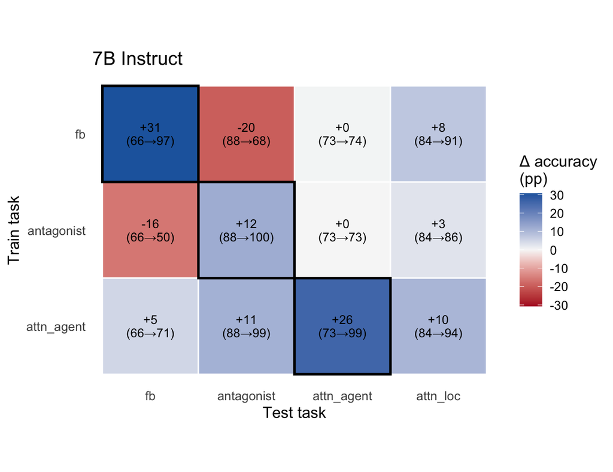

### 13B Stage 1

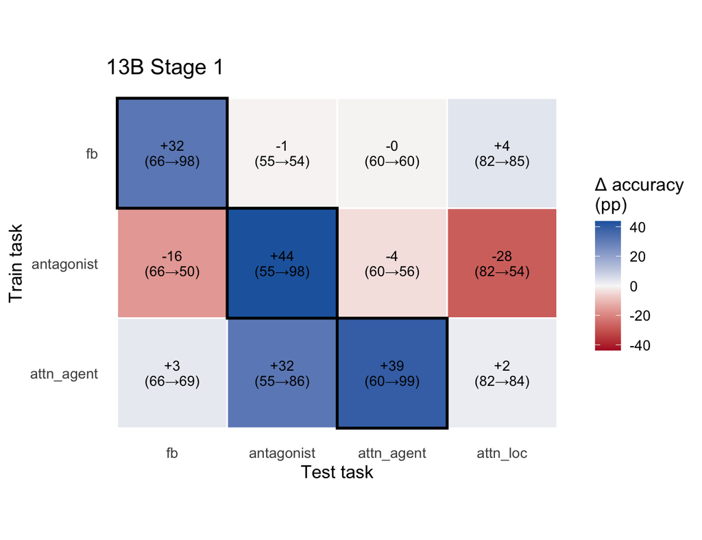

### 13B Stage 2

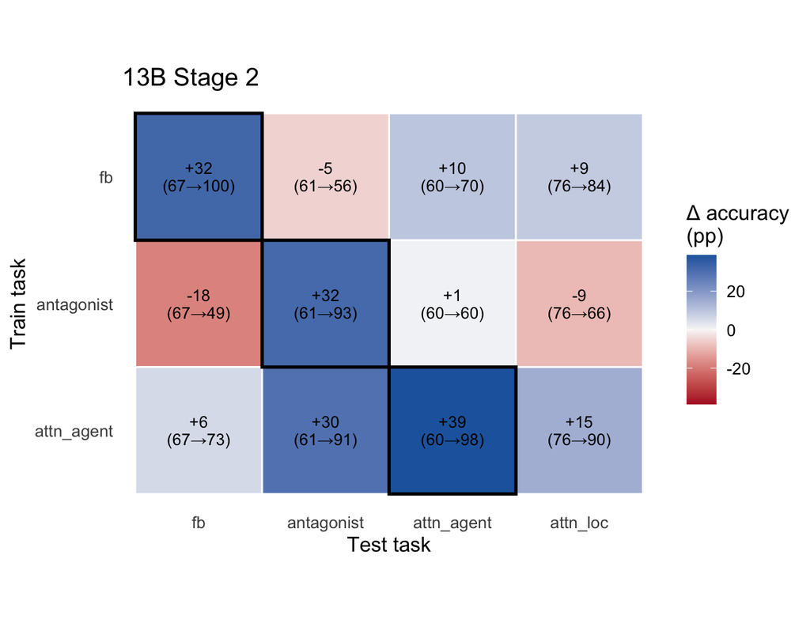

### 13B Pretrained

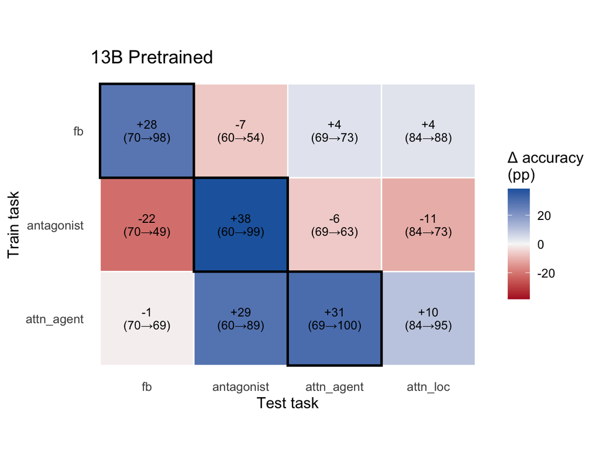

### 13B SFT

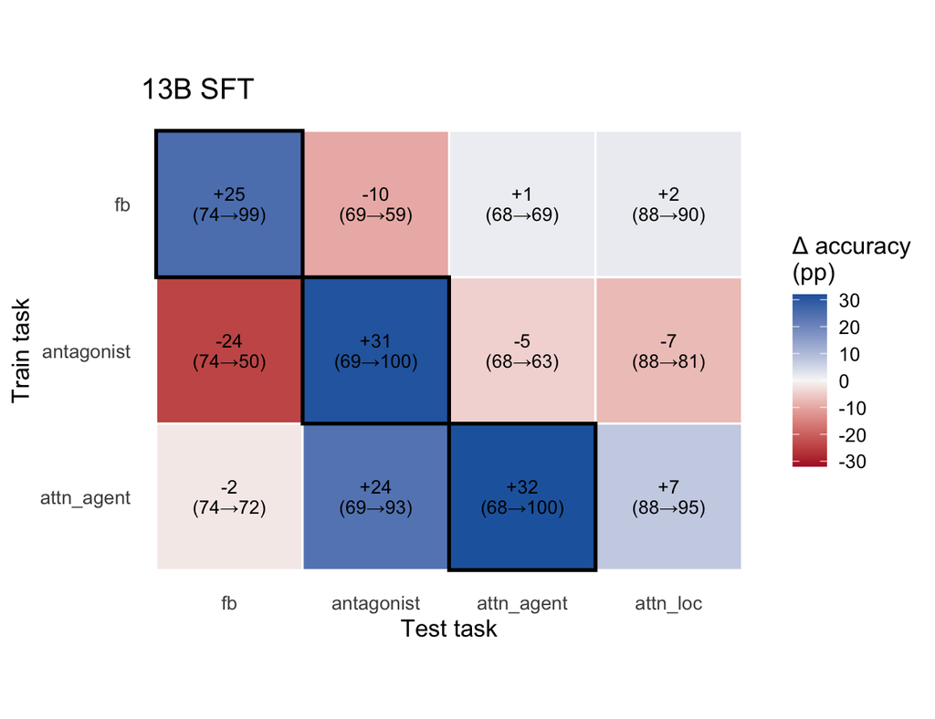

### 13B DPO

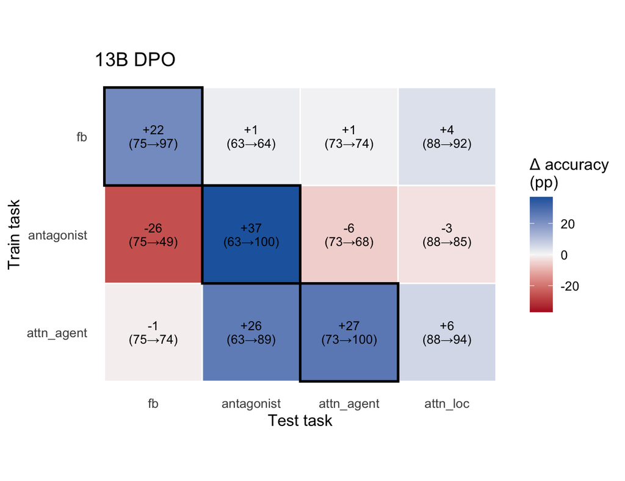

### 13B Instruct

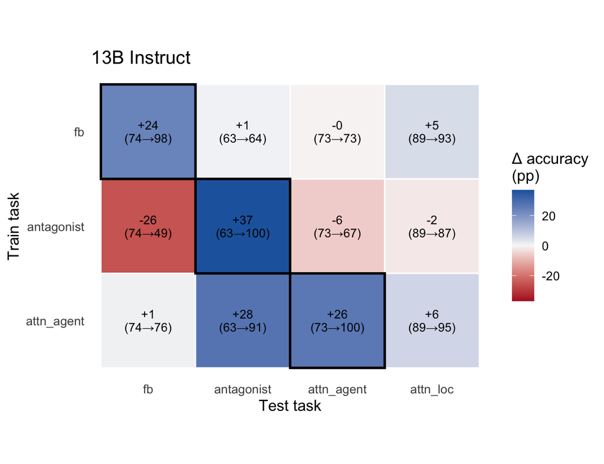

## Accuracy by condition

Same layout as “Gain by condition”, but showing the change in accuracy (percentage points). Error bars are ±1 SE across seeds. Labels under each bar show accuracy before → after fine-tuning.

### 7B Stage 1

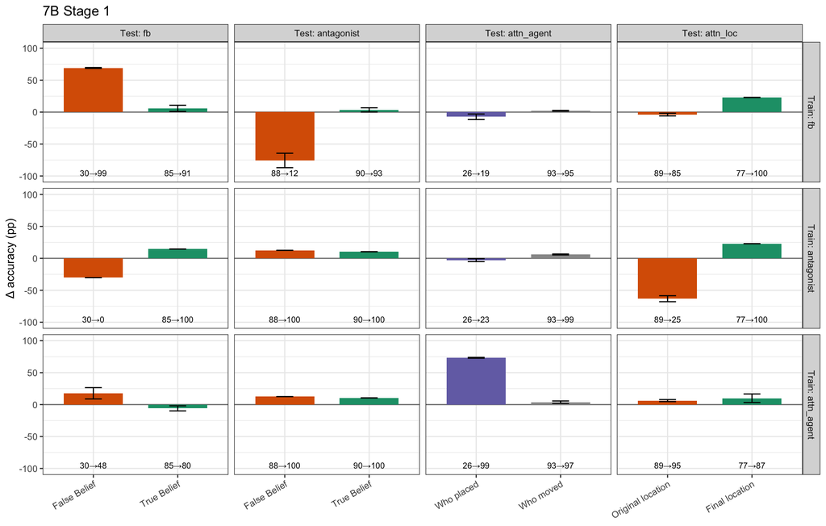

### 7B Stage 2

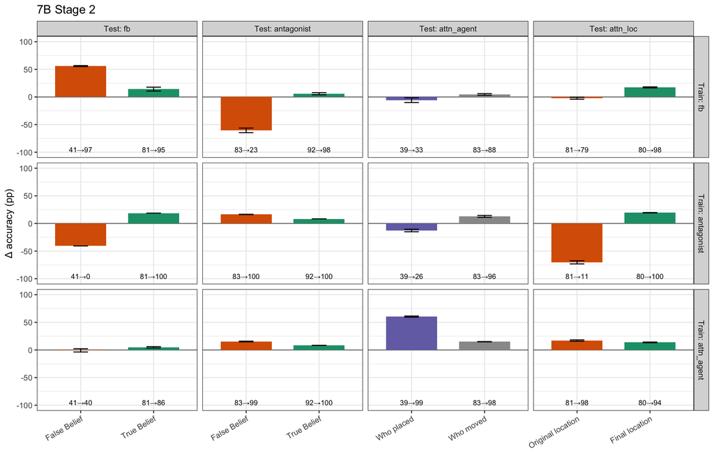

### 7B Pretrained

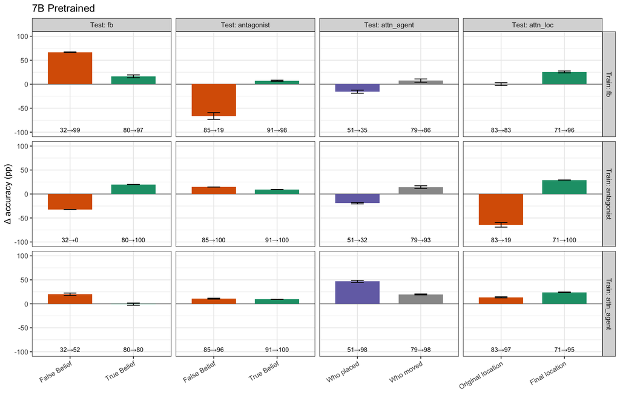

### 7B SFT

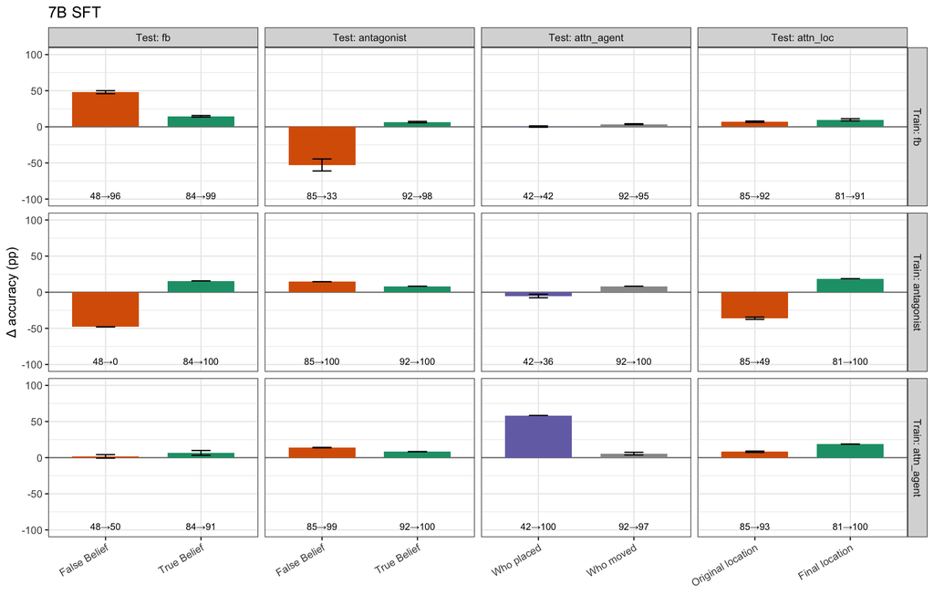

### 7B DPO

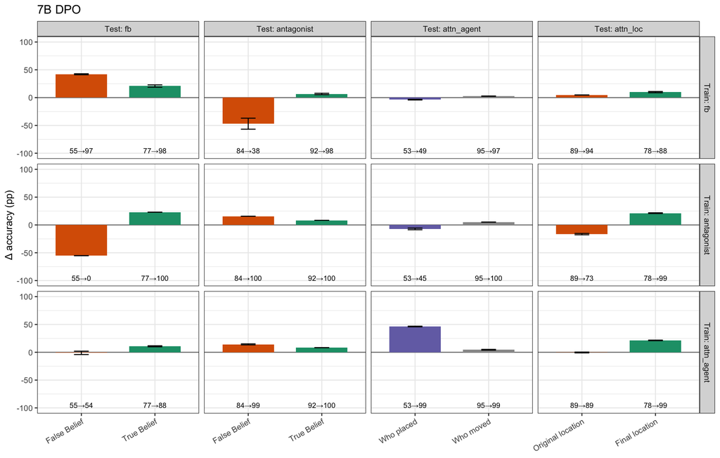

### 7B Instruct

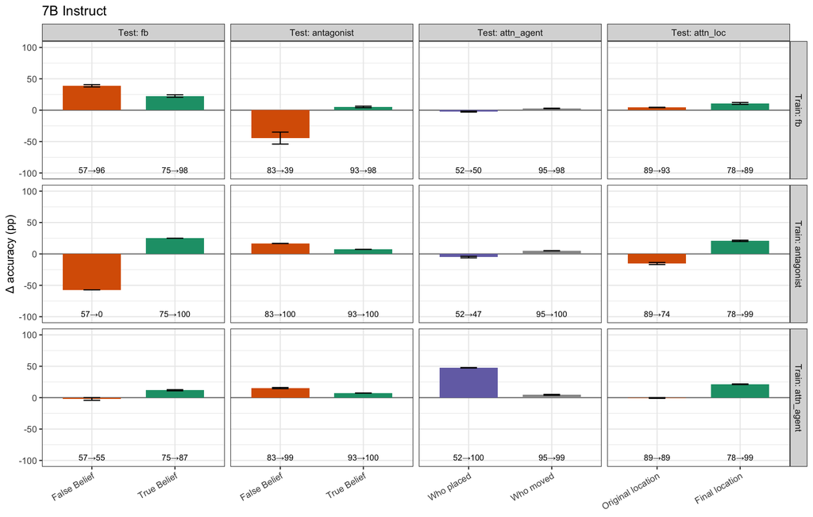

### 13B Stage 1

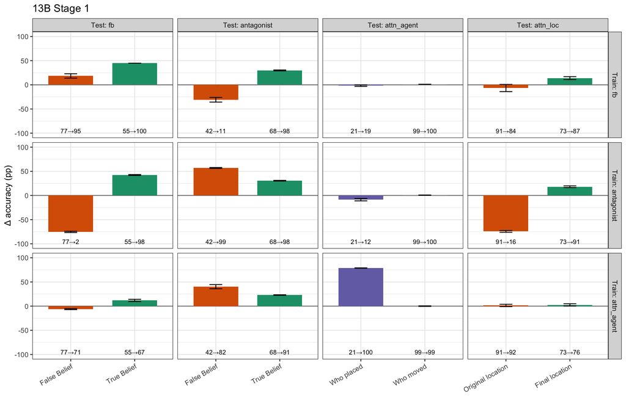

### 13B Stage 2

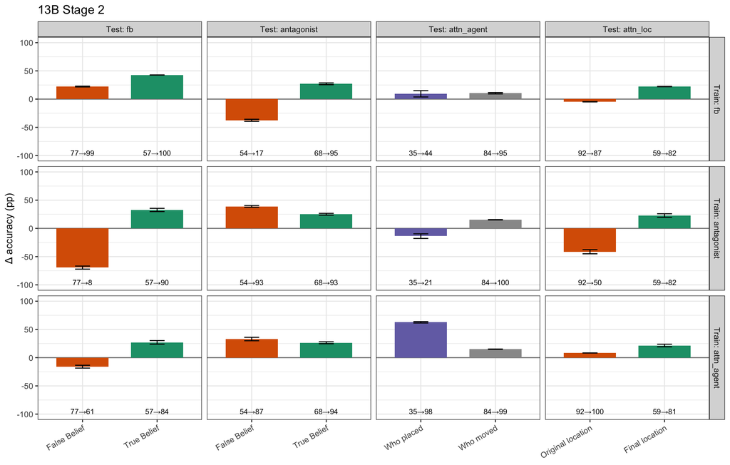

### 13B Pretrained

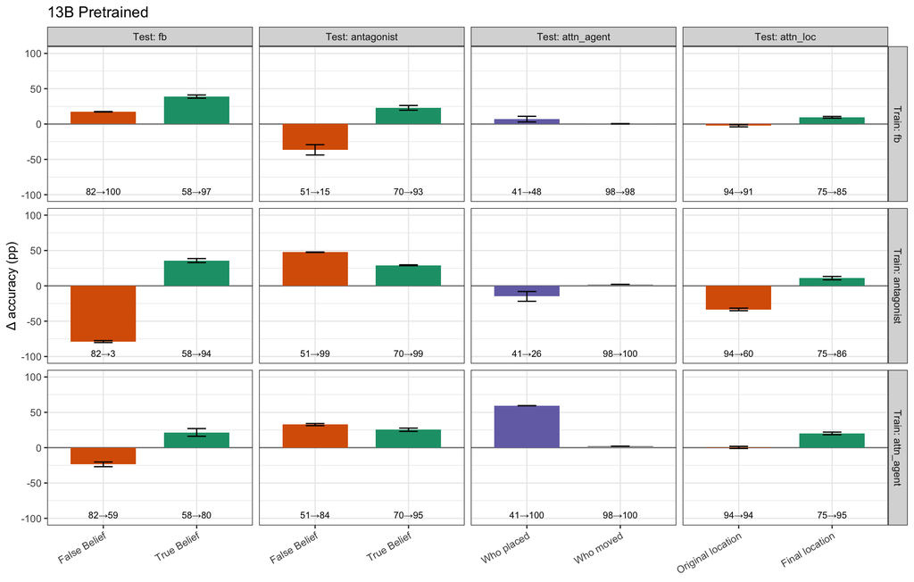

### 13B SFT

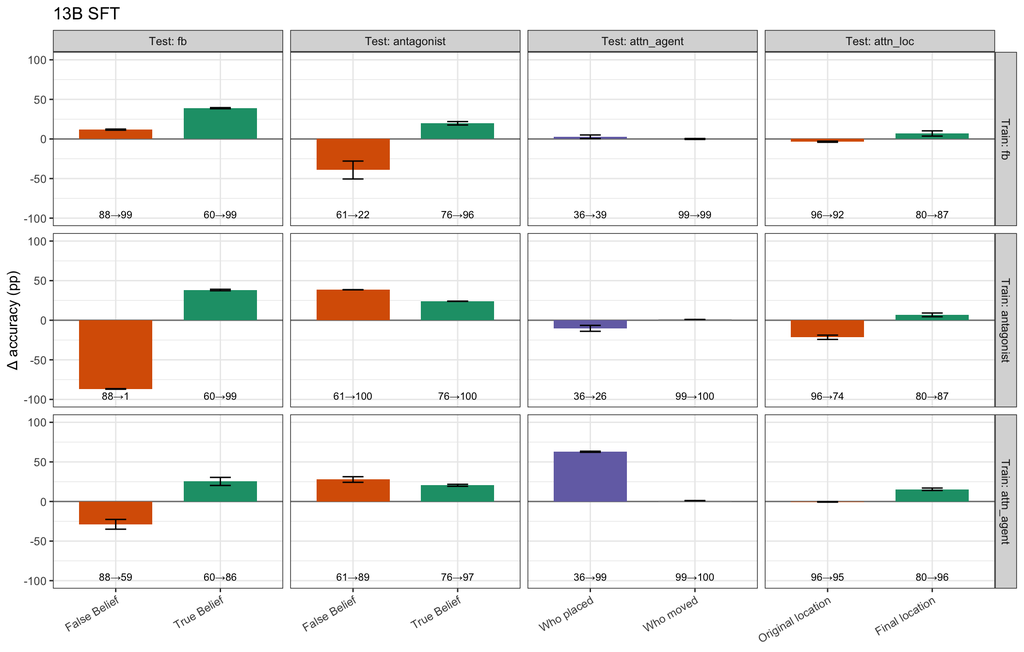

### 13B DPO

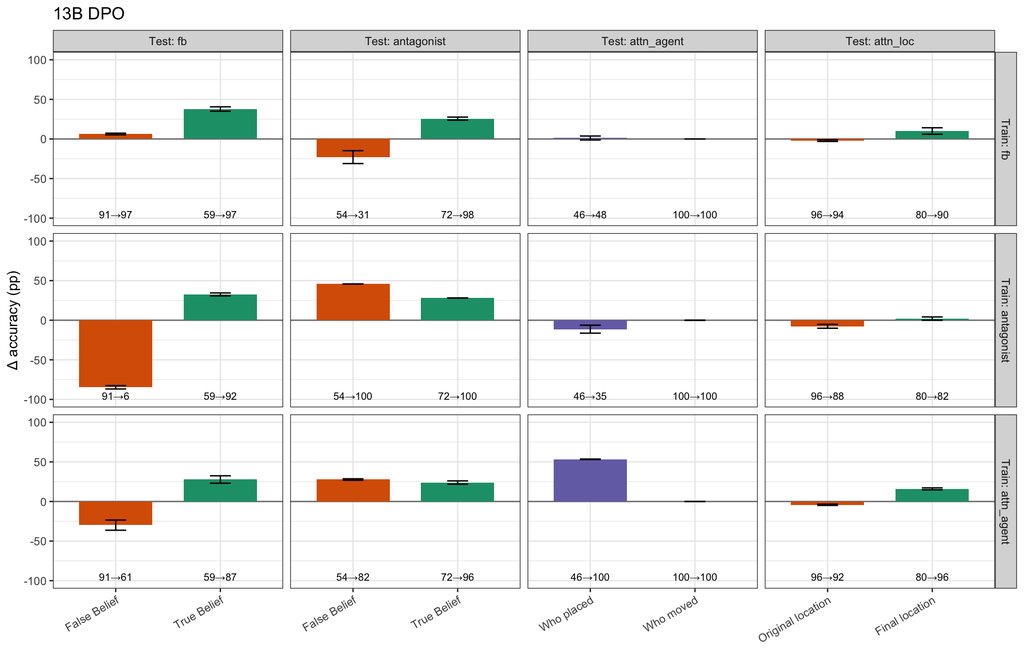

### 13B Instruct

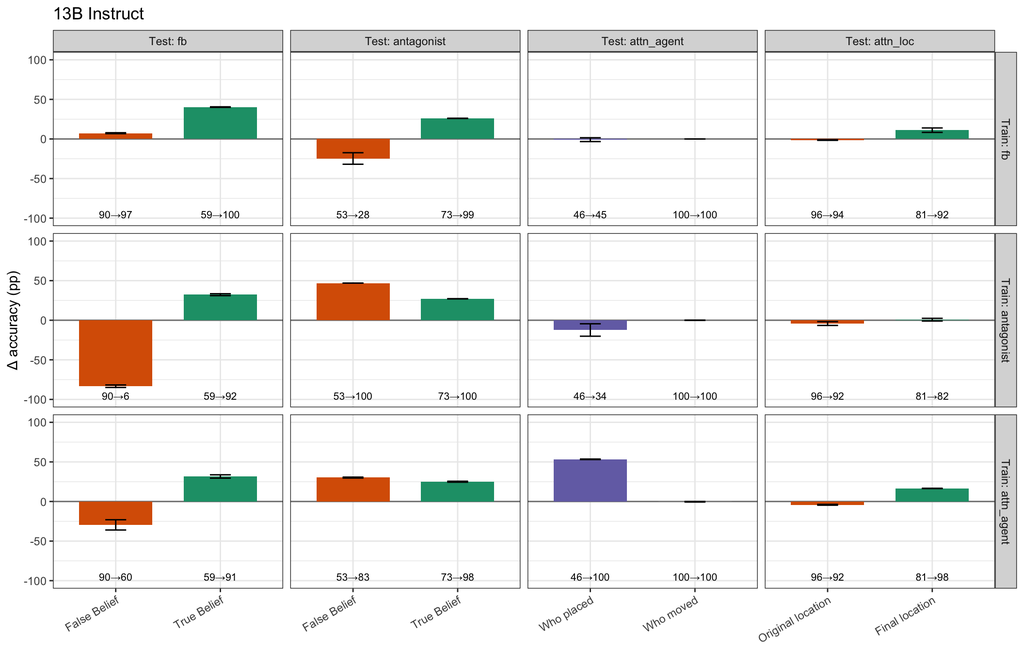

## Accuracy change across training stages

One figure per test task. Each line is the change in accuracy (percentage points) on that test task after fine-tuning on the row’s training task, at each training stage. Columns are model sizes. Error bars are ±1 SE across seeds. Stages: Stage 1 (last stage-1 checkpoint), Stage 2 (last stage-2 checkpoint), Pretrained (final base model), then the SFT, DPO and Instruct models.

### Test: fb

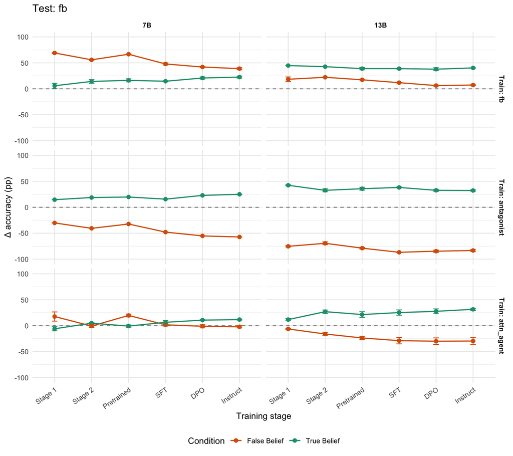

### Test: antagonist

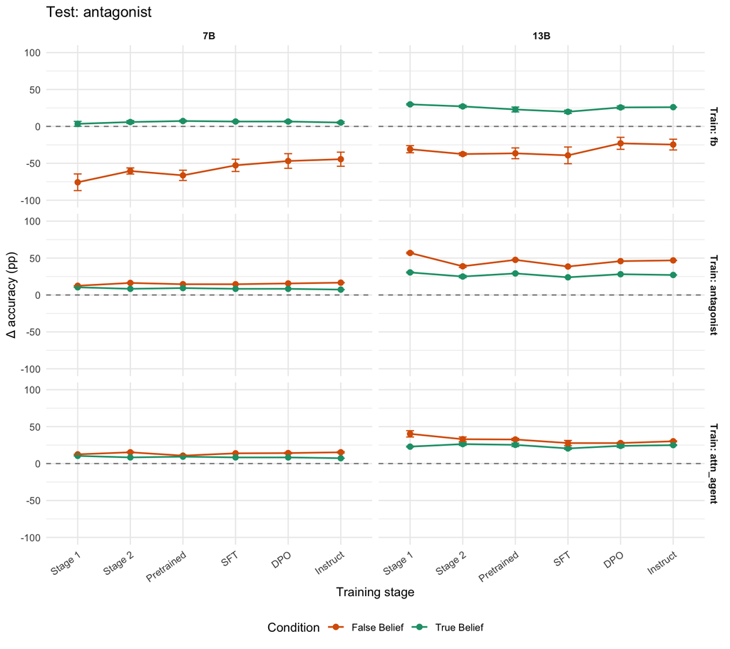

### Test: attn_agent

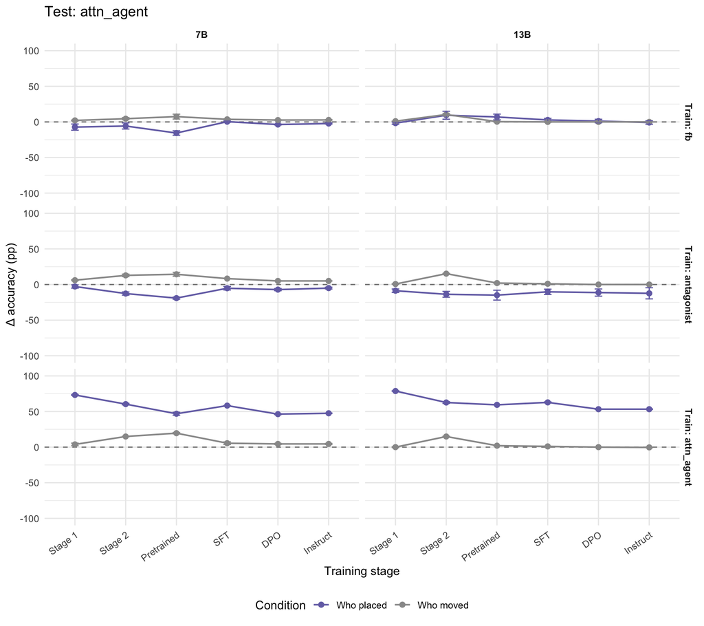

### Test: attn_loc

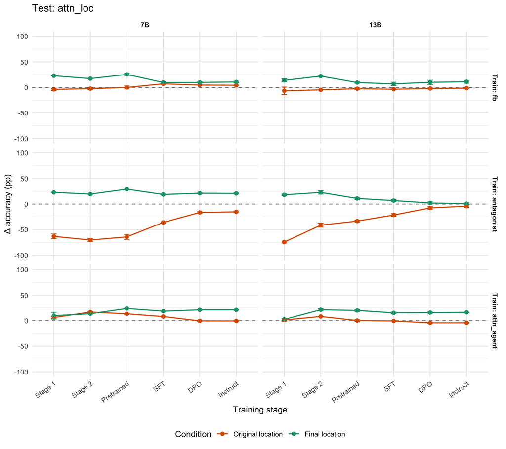

## Accuracy before and after fine-tuning, across stages

Same layout as above, but showing accuracy itself rather than the change: dashed lines are the base model, solid lines are after fine-tuning. This makes ceiling and floor effects visible (a condition already near 100% has little room to improve).

### Test: fb

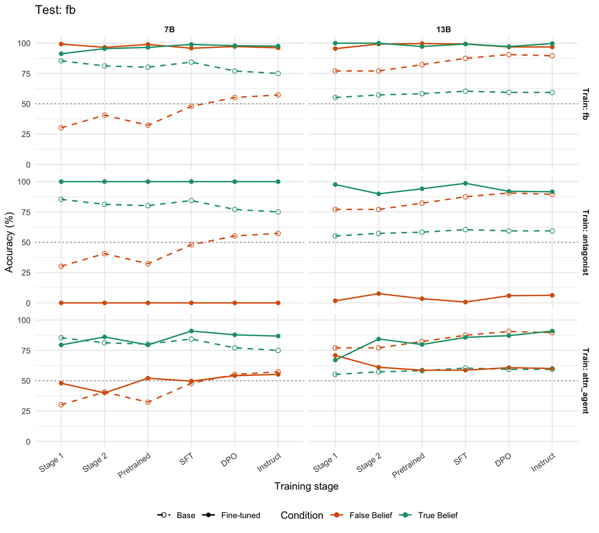

### Test: antagonist

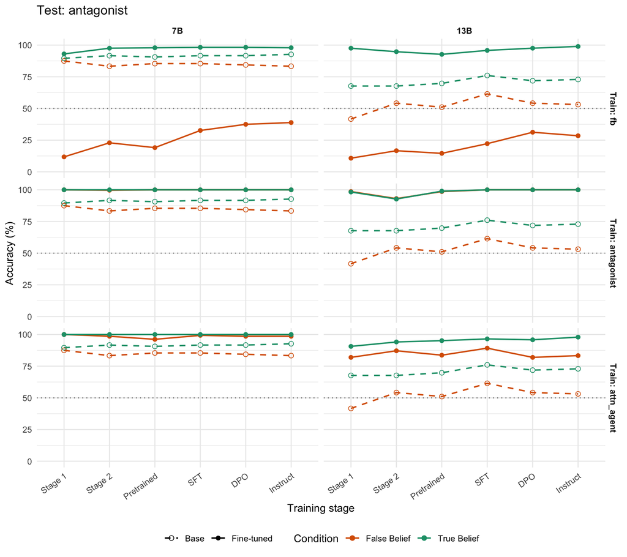

### Test: attn_agent

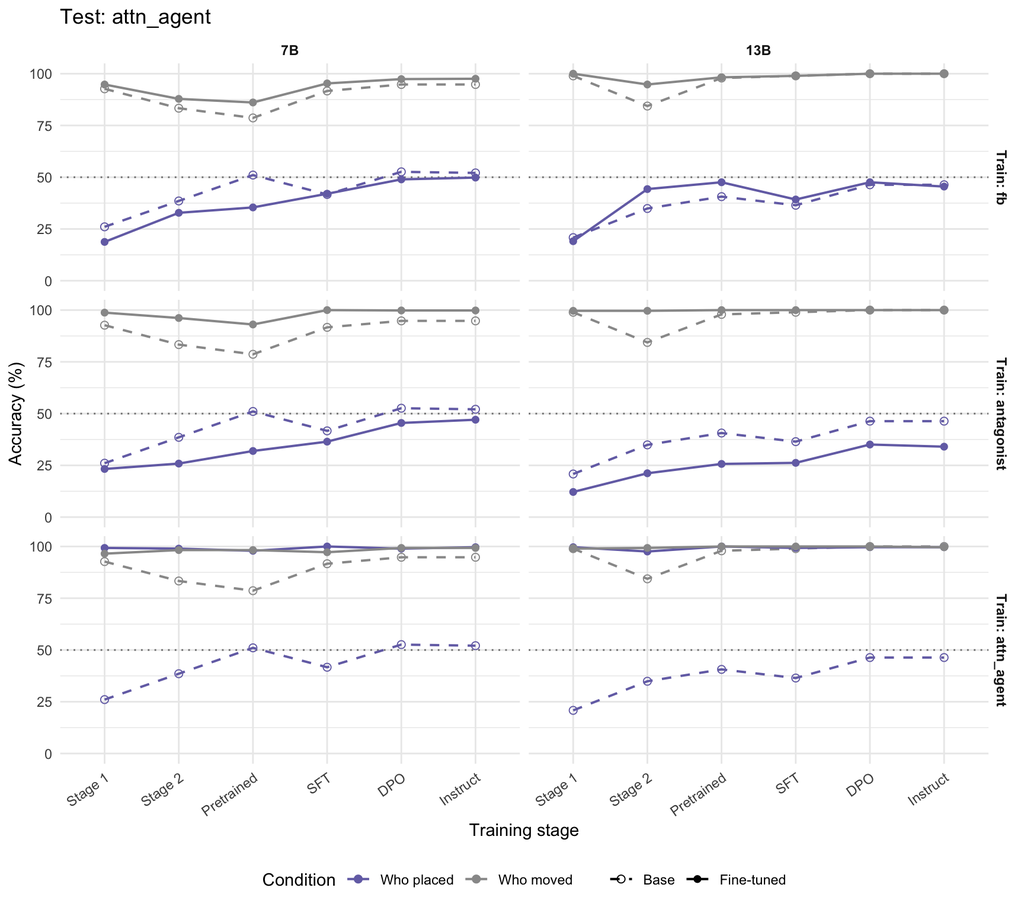

### Test: attn_loc

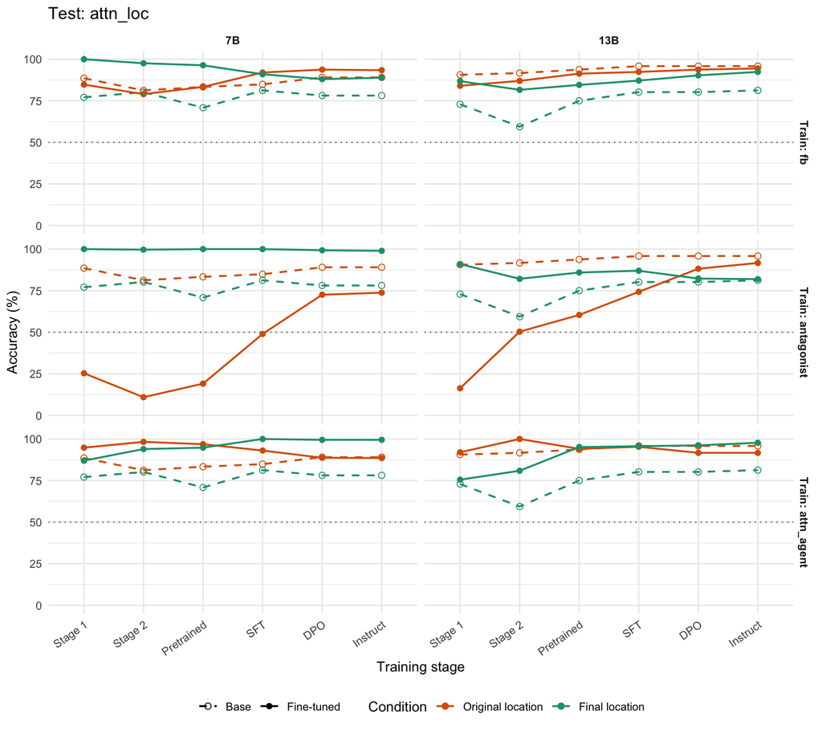

## Explicit vs. implicit probe

Mean gain on fb and antagonist, split by how the final question is worded (explicit “thinks the X is in the” vs. implicit, e.g. “goes to get the X from the”). Error bars are ±1 SE across seeds.

### 7B Stage 1

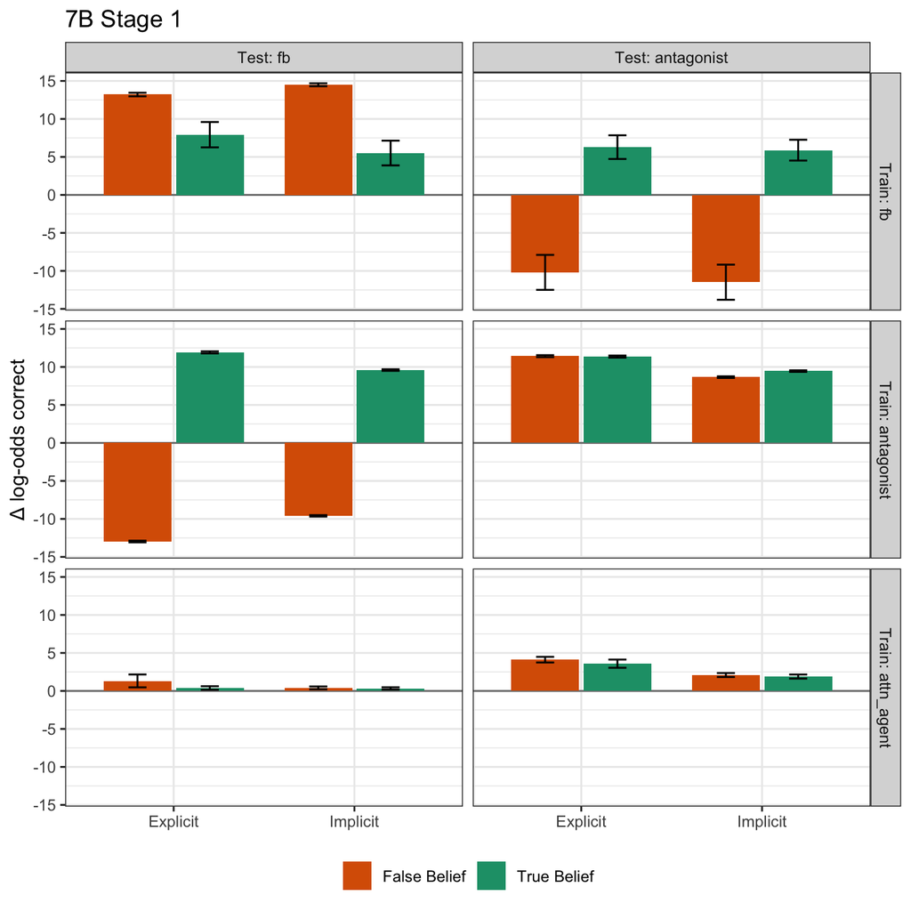

### 7B Stage 2

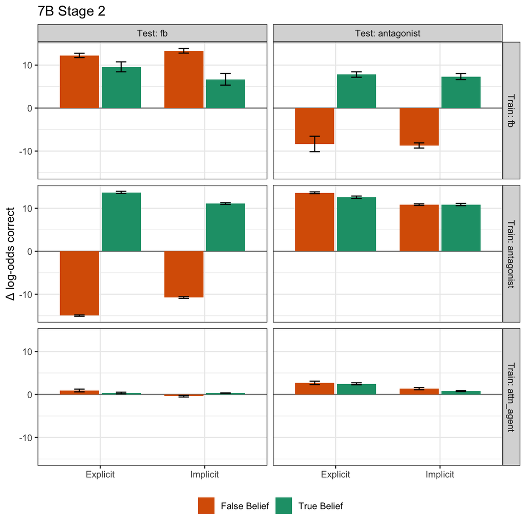

### 7B Pretrained

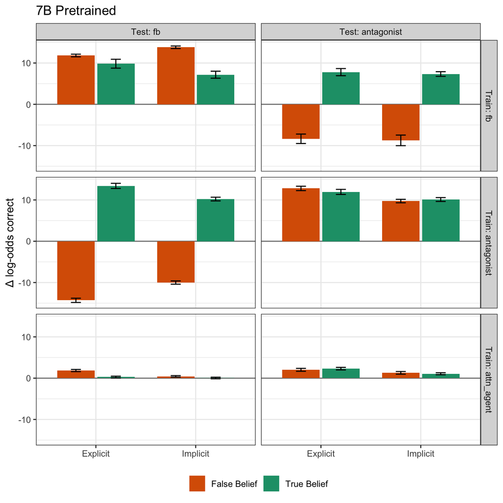

### 7B SFT

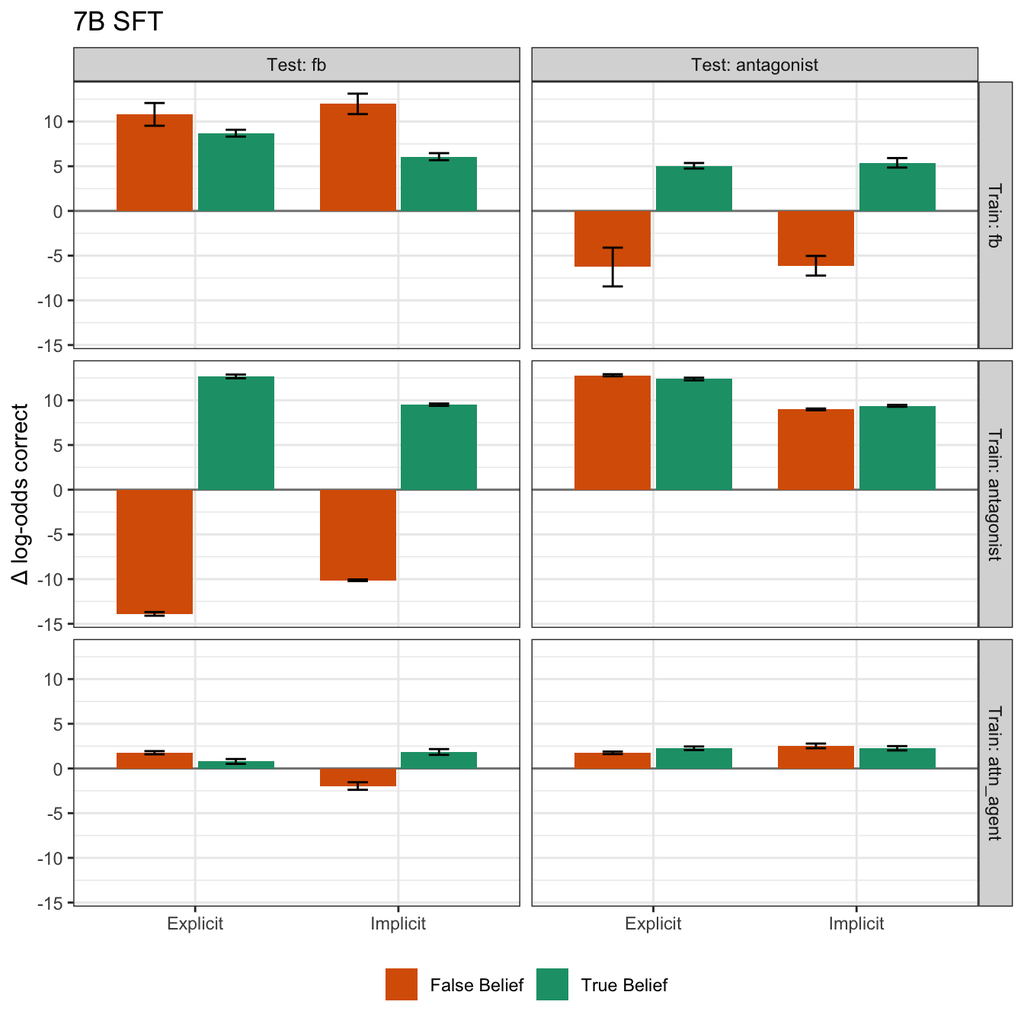

### 7B DPO

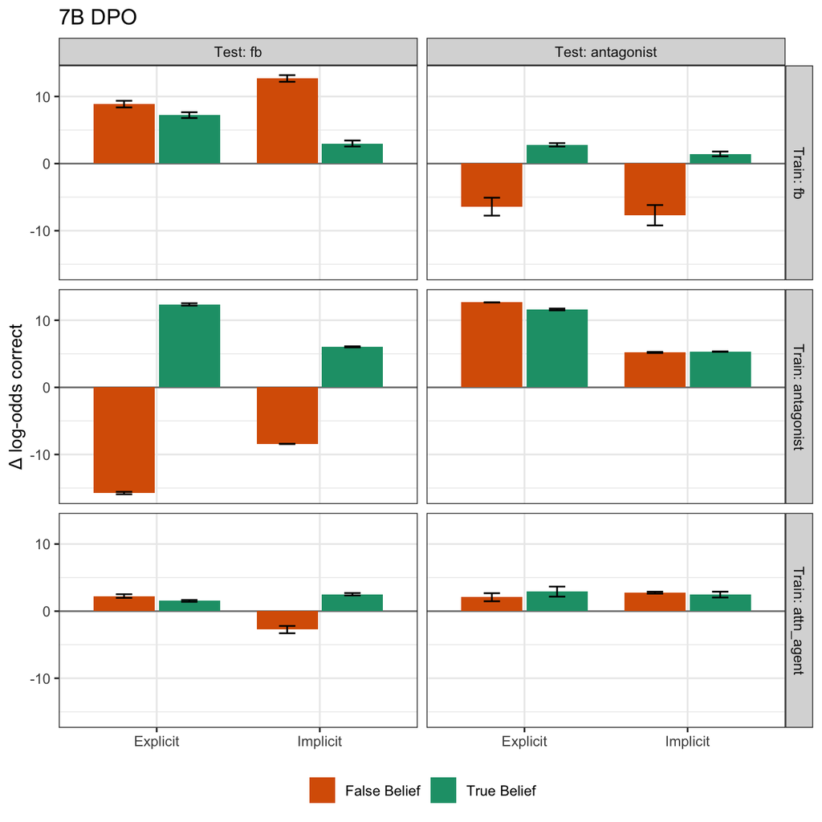

### 7B Instruct

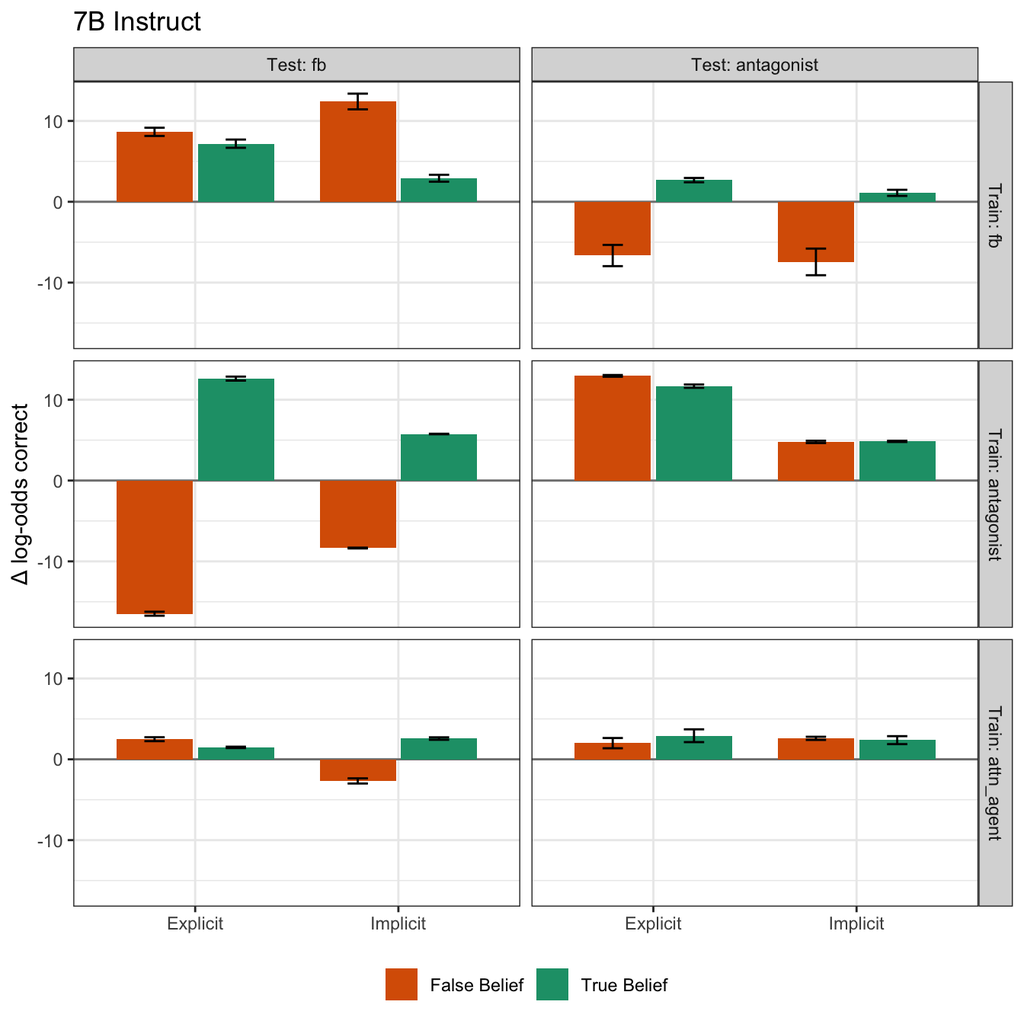

### 13B Stage 1

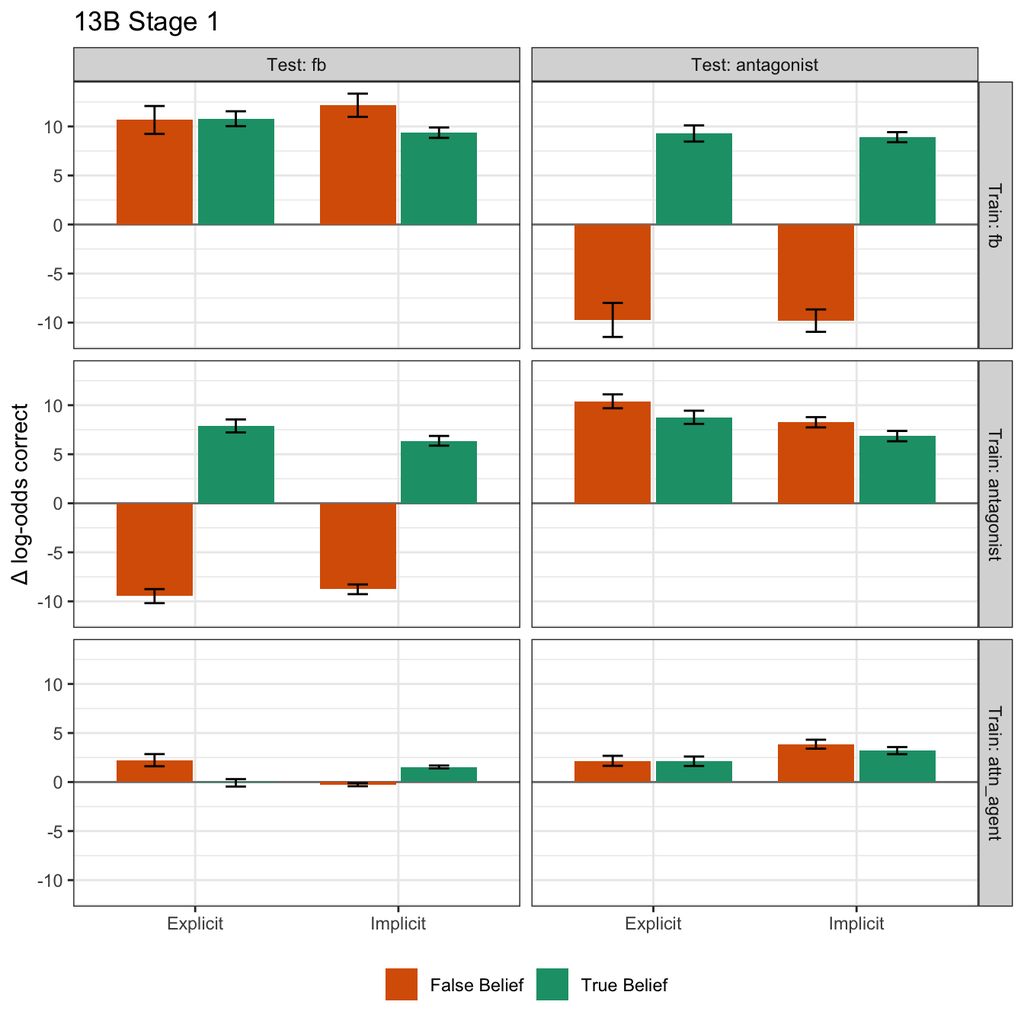

### 13B Stage 2

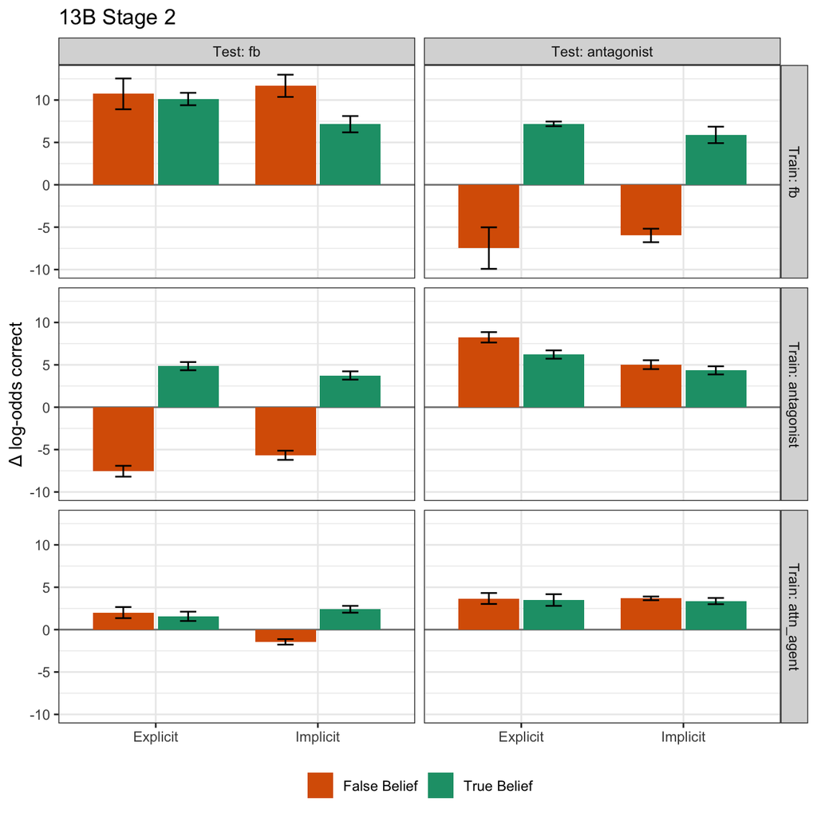

### 13B Pretrained

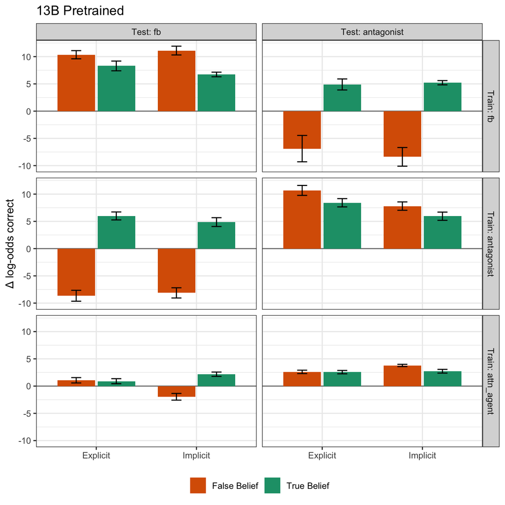

### 13B SFT

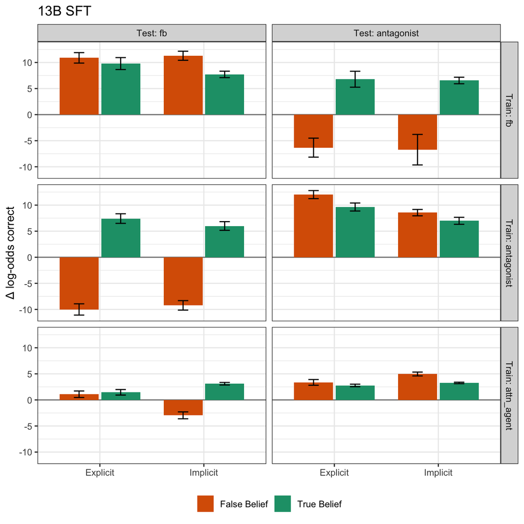

### 13B DPO

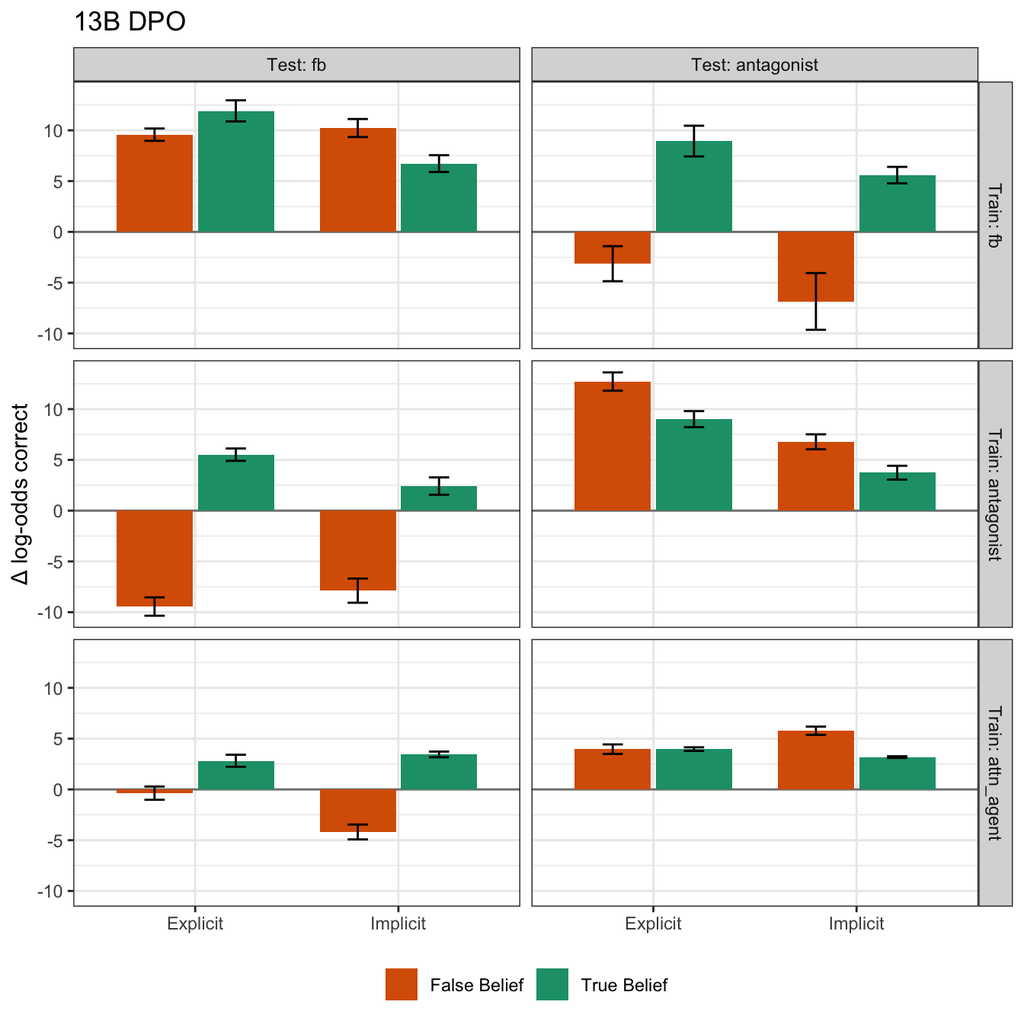

### 13B Instruct

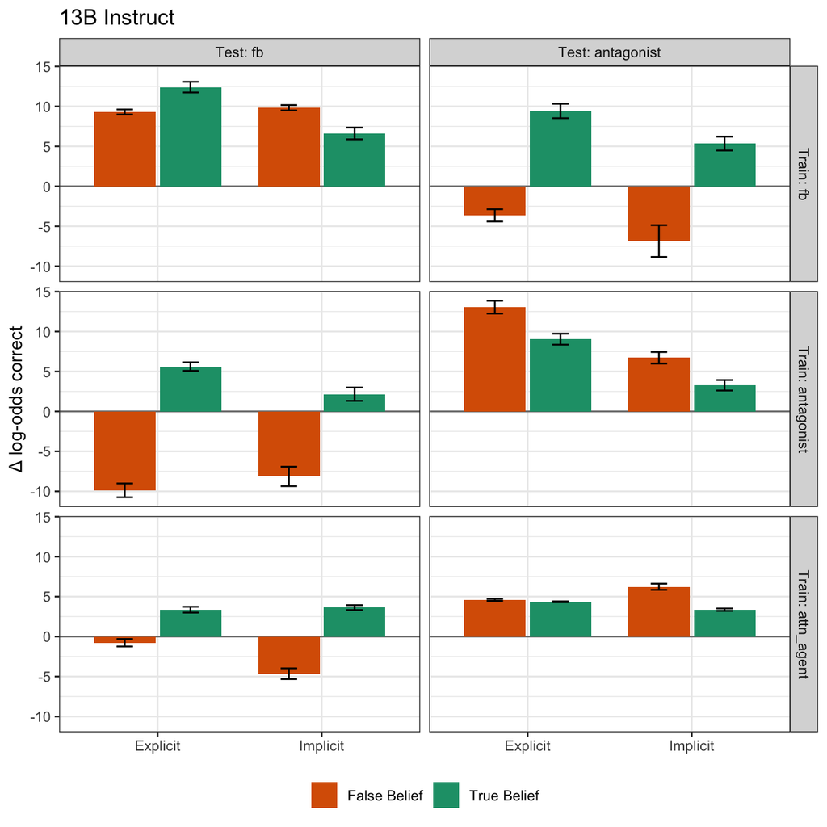

## Item-level: before vs. after

Each point is one item (averaged over seeds): log-odds of the correct answer for the base model (x) and after fine-tuning (y). Points above the diagonal improved; points right of the vertical line were already correct before fine-tuning, and points above the horizontal line are correct after.

### 7B Stage 1

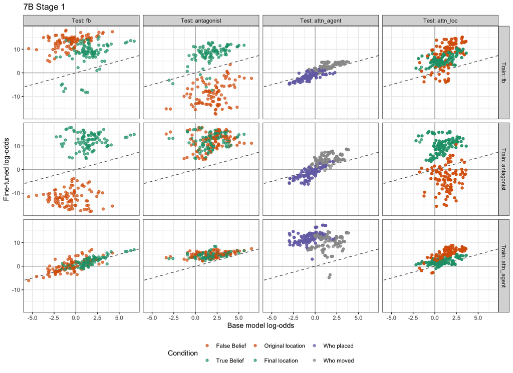

### 7B Stage 2

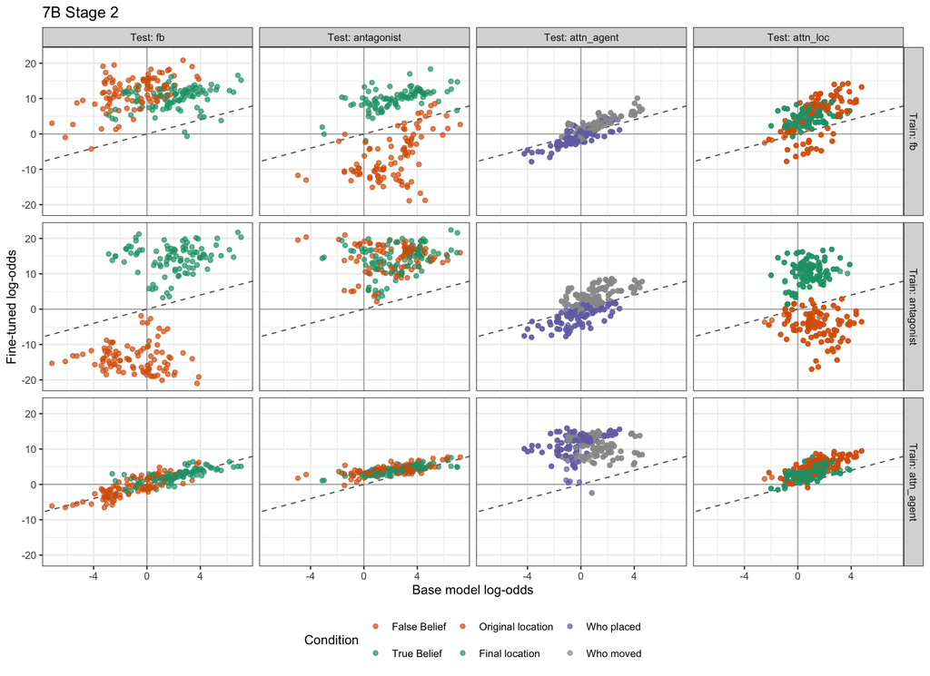

### 7B Pretrained

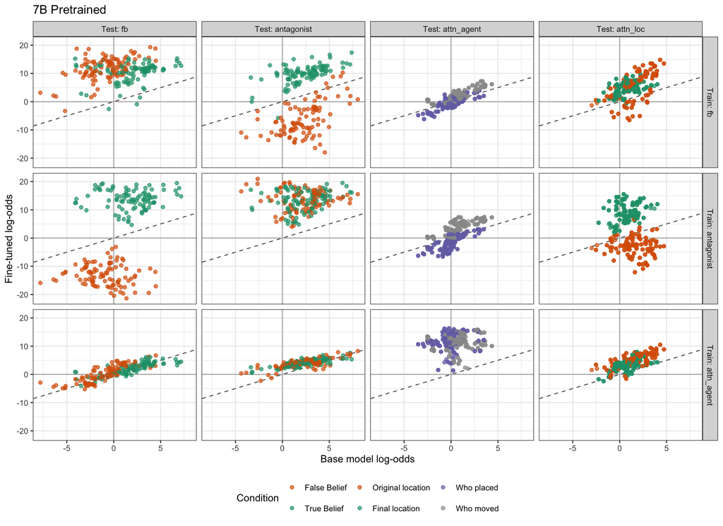

### 7B SFT

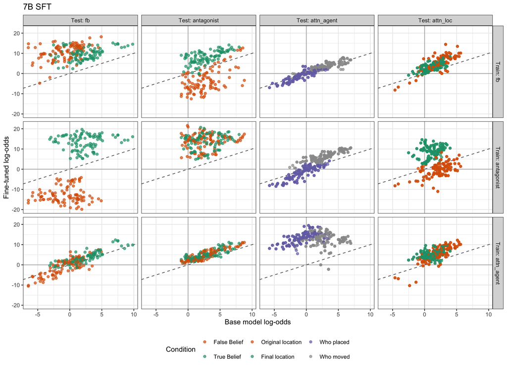

### 7B DPO

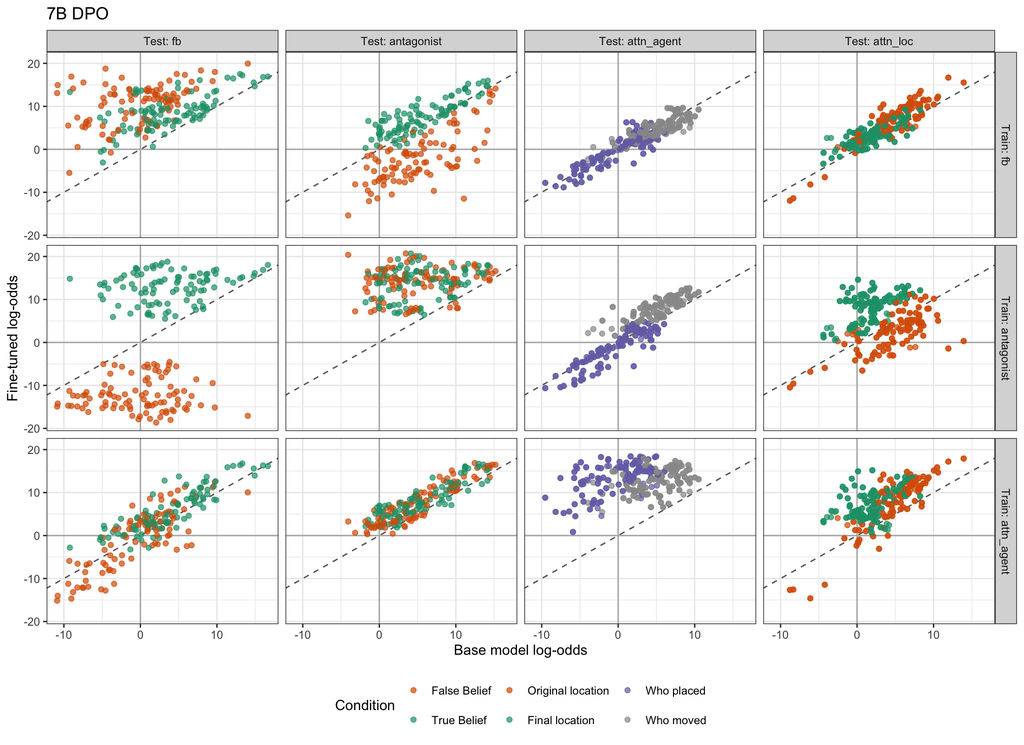

### 7B Instruct

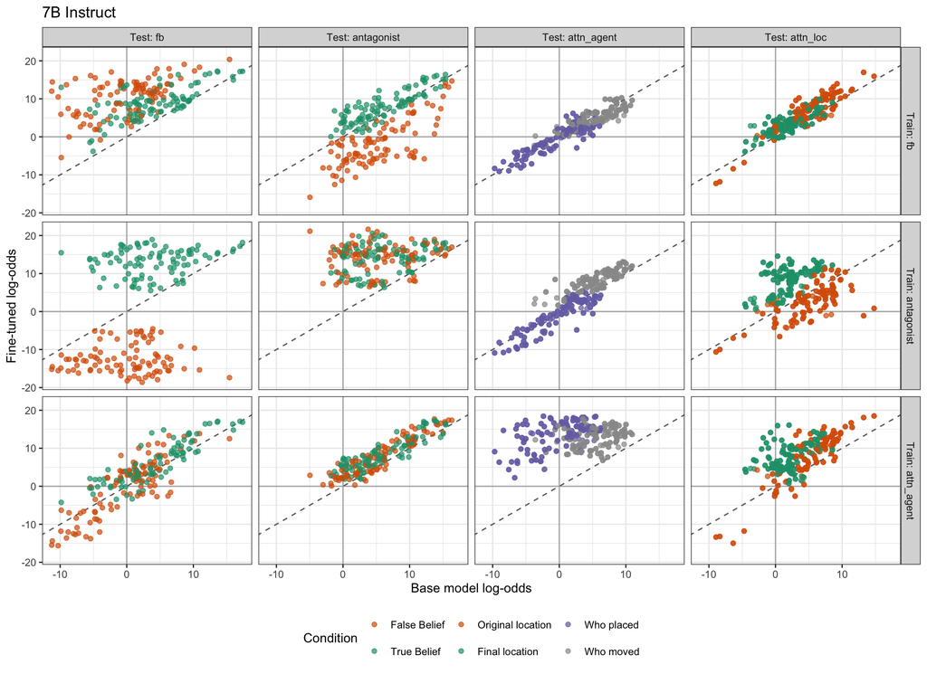

### 13B Stage 1

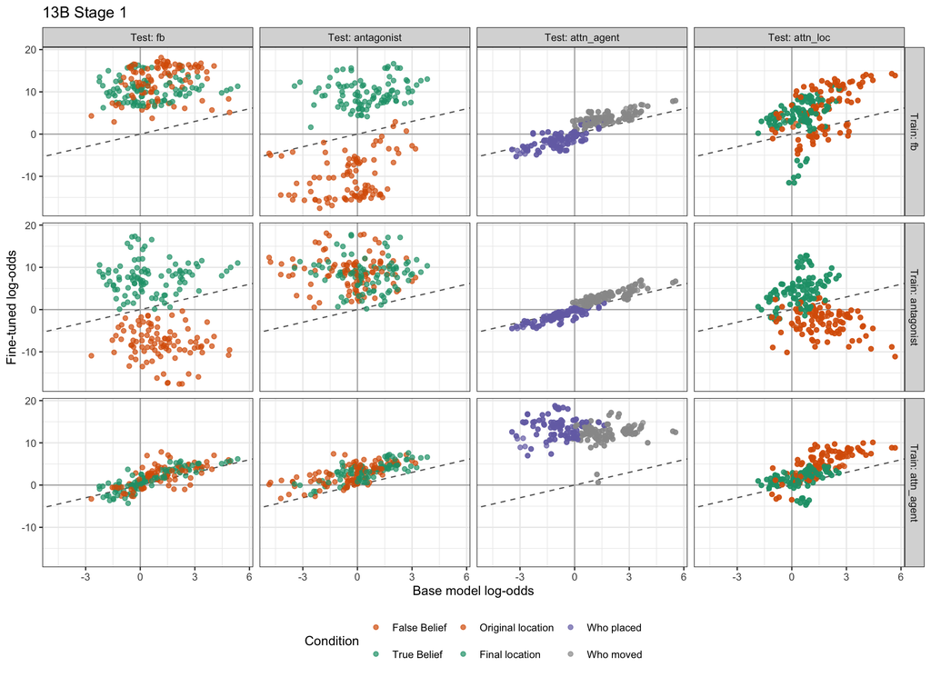

### 13B Stage 2

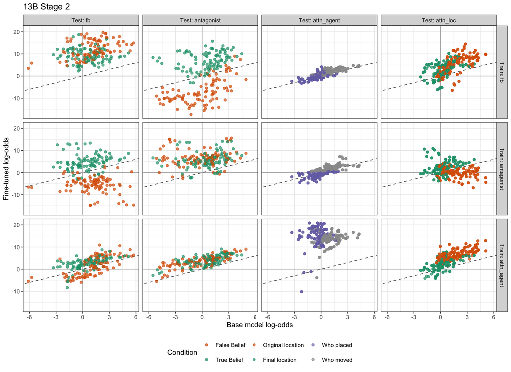

### 13B Pretrained

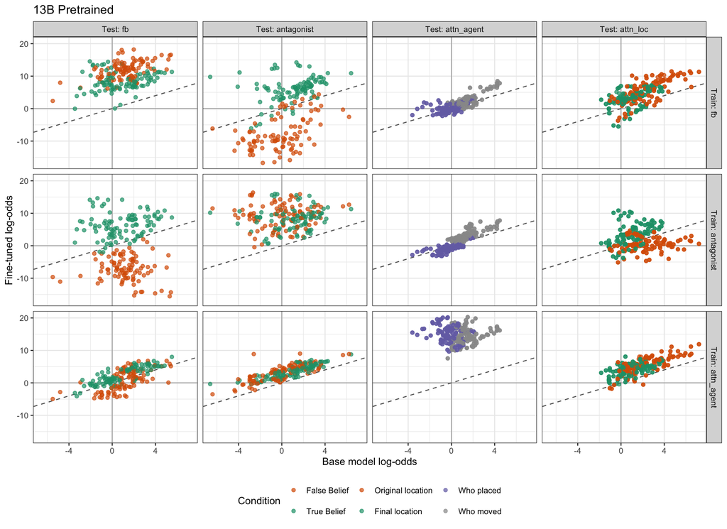